# MSDM5059 Tutorial 9 - Processes on Networks I

## Table of content

1. Site Percolation
2. Network syncronization

```python
import networkx as nx
import numpy as np
import matplotlib.pyplot as plt
%matplotlib inline

import random
from scipy.special import binom
from scipy.integrate import solve_ivp
```

# 1. Site percolation

The site percolation is the removal of some fraction of its vertices in a network, along with the edges connected to them. It is closely related to many real-world phenomena. For example, removal of certain hubs in a network can disconnect internet users from the central network; Vacinnation of an individual in a population can prevent the spreading of an infectious disease. Understanding the theory behind can help us to examine if a given network is resilience enough, i.e. it can function as a giant cluster even if certain vertices are removed.

Here I will demonstrate the percolation processes using the two network models:

- Erdös-Rényi model to represent homogenous network
- Barabási-Albert model to represent scale free network

```python
er = nx.fast_gnp_random_graph
ba = nx.barabasi_albert_graph

# You need to demonstrate the percolation process on a real network in your final project.
```

## 1.1. Theories

### 1.1.1 Uniform random removal

The simplest case of site percolation is the uniform random removal of nodes. Whether a node is kept or removed is solely decided by an occupation probability $\phi$:

- $\phi=1$ indicates that all nodes are present.
- $\phi=0$ indicates all nodes are removed.

At large $\phi$, we can observe that the nodes remain connected, forming a giant component. Then when one decreases $\phi$, the network starts to break apart, tearing down the giant component, and eventually the nodes become disconnected and the giant component disappears. We are interested in the question: at what $\phi$ will the giant component disappear?

The model starts from a configuration model with degree distribution $P(k)$ and excess degree distribution $Q(k) = \frac{(k+1)P(k+1)}{\langle k \rangle}$ (The likelihood of finding a neighbour of degree $k$).

**Step 1 -** First define the two generating functions from the distributions

\begin{align*} \begin{cases} g_0(z) &=\ \sum_{k=0}^\infty P(k)z^k \\ g_1(z) &=\ \sum_{k=0}^\infty Q(k)z^k \end{cases}\,. \end{align*}

**Step 2 -** Next define $u$ as the **probability of finding one edge NOT in the giant component**, e.g. it connects two nodes but the nodes are not in the giant component. Then the probability of finding a node NOT connected to the giant component can be expressed in terms of the generating function

\begin{align*} g_0(u) = \sum_{k=0}^\infty P(k)u^k \end{align*}

since a node has a probability $P(k)$ of being degree $k$, and it has a probability $u^k$ that all of its $k$ edges not connected to the giant component.

**Step 3 -** The parameter we are interested in is the fraction of vertices $S(\phi)$ that are in the giant component, as a function of $\phi$. Notice that a node is in the giant component if and only if it is simultaneously

1. Not removed (Prob. $=\phi$)
2. Connected to the giant component (Prob. $=1-g_0(u)$).

Thus,

\begin{align*} S(\phi) = \phi[1-g_0(u)] \end{align*}

**Step 4 -** What remains is to solve $u$ as a function of $\phi$. For a node with an edge NOT connected to the giant component, it can either be

- The node is already removed, so this edge is absent. (Prob. $=1-\phi$)
- The node is present and this edge is connected to a neighbour of degree $k+1$, but the neighbour's remaining $k$ edges do not connect to the giant component. (Prob. $= \phi g_1(u) = \phi\sum_{k=0}^\infty Q(k)u^k $)

Therefore $u$ satisfies the equation $u = 1-\phi + \phi g_1(u)$. By solving graphically, we can find that

1. Since $g_1(1) = \sum_{k=0}^\infty Q(k) = 1$, $u=1$ is a trivial solution. This refers to the case which none of the nodes are in the giant component, and corresponds to $S=0$.
2. A non-trivial solution exist only if $\phi$ is above the critical value $\phi_c = \frac{1}{g_1'(1)} = \frac{\langle k\rangle}{\langle k^2 \rangle - \langle k\rangle}$.

The quantity $\phi_c$ is an important measure to how resilience the network is, since only if $\phi > \phi_c$ can a giant component be found ($S>0$). For example, if $\phi_c$ is large, we only need to remove a small portion of nodes to break the giant component. Then we can approximate $u$ by Taylor expanding $g_1(u)$:

\begin{align*} g_1(u) &= 1+ \frac{u-1}{\phi}\\ &= g_1(1) + (u-1)g_1'(1) + \frac{1}{2}(-1)^2g_1''(1) + O(u-1)^3 \\ &= 1 + \frac{u-1}{\phi_c} + \frac{1}{2}(-1)^2g_1''(1) + O(u-1)^3 \\[1em] \Rightarrow\quad u-1 &= \frac{2}{g_1''(1)}\frac{\phi_c-\phi}{\phi_c\phi} + O(u-1)^2 \,. \end{align*}

And the size of the giant component $S$ by Taylor expanding $g_0(u)$ and substitute the above result

\begin{align*} g_0(u) &= g_0(1) + (u-1)g_0'(1) + O(u-1)^2 \\ &= 1 + \frac{2\langle k\rangle}{g_1''(1)}\frac{\phi_c-\phi}{\phi_c\phi} + O(u-1)^2 \\[1em] \Rightarrow\quad S = \phi[1-g_0(u)] &= \frac{2\langle k\rangle}{g_1''(1)}\frac{\phi-\phi_c}{\phi_c} + O(u-1)^2 \end{align*}

### 1.1.2 Targeted node removal

In some network, we are more interested in the percolation process under specific schemes of node removal. For example, the failure of a high degree hub can paralyze the large number of users in the internet; Infection to a high degree node clearly raises the risk to many others. Here we only discuss the removal in the order of the nodes'degrees.

**Step 1 -** This time we let $\phi_k$ be the occupation probability, which is a function of degree $k$. Again, let $u$ be the probability of a node having one edge NOT connected to the giant component. For a node of degree $k$, its probability to belong to the giant component is thus

\begin{align*} S_k = \phi_k(1-u^k) \,. \end{align*}

And the average size of the giant component is the average over the degree distribution $P(k)$.

\begin{align*} S = \sum_{k=0}^\infty P(k)S_k = \sum_{k=0}^\infty P(k)\phi_k(1-u^k) \,. \end{align*}

**Step 2 -** We can also solve $u$ as a function of $\phi_k$ in a similar fashion. For a neighbour with degree $k+1$ that is not connected to the giant component,

- The neighbour is already removed, and so this edge is absent. (Prob. $=1-\phi_{k+1}$)
- The neighbour is present and but all its $k+1$ do not connect to the giant component. (Prob. $=\phi_{k+1}u^k$)

Then $u$ is the average over the excess degree distribution $Q(k)$, i.e.

\begin{align*} u = \sum_{k=0}^\infty Q(k)(1-\phi_{k+1}+\phi_{k+1}u^k) \,. \end{align*}

By solving graphically, we can find that

1. $u=1$ is a trivial solution. This means none of the nodes are in the giant component and corresponds to $S=0$.
2. A non-trivial solution exist only if $\sum_{k=0}^\infty (k-1)Q(k)\phi_k >1$. This determine the critical occupation probability for a giant component to exist.

For example, if we want to see what it looks like after removing all nodes with degree higher than $k_0$, we can set

\begin{align*} \phi_k = \begin{cases} 1 & \text{if } k<k_0 \\ 0 & \text{else} \end{cases} \end{align*}

Then $S$, $u$ and the critical occupation probability can be numerically computed once $\phi_k$ is specified.

## 1.2 Algorithm

### 1.2.1. A faster algorithm

The intuitive way to simulate percolation is to go through every nodes on a network, remove them one by one by probability $1-\phi$ and measure $S$ the size of the largest component by calling `nx.connected_components()`. Then we have to repeat the process many times to get an average $S(\phi)$. This method is however too time consuming if we want to keep track on the variation of $S$ against a range of $\phi$.

As suggested by Newman [1], a faster alternative is to fix the number of occupied nodes $r$ and compute the average size of the largest component $\langle S_r \rangle$ through many trials. In uniform random removal, since the probability of having $r$ nodes occupied is equal to the $p_r = \binom{n}{r}\phi^r(1-\phi)^{n-r}$ under a fixed occupation probability $\phi$, $S(\phi)$ computed by

\begin{align*} S(\phi) = \sum_{r=0}^n p_rS_r = \sum_{r=0}^n\binom{n}{r}\phi^r(1-\phi)^{n-r} \langle S_r \rangle \end{align*}

For removal of nodes in a specific order, the number of nodes remain must equal to $N\phi$. So we simply have

\begin{align*} S(\phi) = S_{N\phi} = S_r \end{align*}

### 1.2.2. Computing $S_r$

We can measure $S_r$ by turning the nodes from unoccupied to occupied one by one while labeling the clusters the nodes belong to, When two clusters join, all of their nodes are relabeled to the same number. By this way we can keep track on the cluster with the highest number of nodes. Here is the summary:

1. Start with a network with no occupied nodes. Initialize an order in which the nodes will be added to the network.
2. Add a vertex in the chosen order. For the $i^\text{th}$ vertex to be added, initialize the index of the cluster it belongs to as $i$.
3. Examine the edges attached to it one by one. If the edge is connected to an occupied node, compare index of cluster of the newly added node and its neighbour. Relabel their index of cluster to be smaller one among themselves.
4. Update the size of the biggest cluster, if newly joined cluster is bigger than any existing cluster.

The method of node removal is determined by the chosen order of node adding. For uniform removal, we can do a random shuffle in each trial; For targeted node removal, for example, removal according to the highest degree, we can starting from the adding the nodes of the lowest degree to the graph.

```python
# if you want to use my code in your project
# You must comment every line to explain what each line is doing

def S_r(g, method):

    N = g.number_of_nodes()

    if method == 'rand':
        deg_seq = g.degree
        deg_seq = random.sample(list(deg_seq),len(deg_seq)) # node adding order = random shuffle
    elif method == 'deg':
        deg_seq = g.degree
        deg_seq = sorted(deg_seq, key=lambda seq: seq[1]) # node adding order = sort by deg
    elif method == 'btw':
        btwness = nx.betweenness_centrality(g)
        deg_seq = sorted(btwness.items(), key=lambda seq: seq[1]) # node adding order = sort by betweenness

    ctl = [0]*N # cluster list
    Sr = [1]*(N+1)

    for i,j in enumerate(deg_seq):
        ctl[j[0]] = i+1
        Sr[i+1] = Sr[i]
        if list(g.neighbors(j[0])) != []:
            for k in list(g.neighbors(j[0])):
                if ctl[k]>0:
                    ctl = [np.minimum(ctl[k],ctl[j[0]]) if (x == ctl[k] or x == ctl[j[0]]) else x for x in ctl]
            Sr_new = ctl.count(ctl[j[0]])
            if Sr_new > Sr[i]:
                Sr[i+1] = Sr_new
    return Sr


def S_phi(phi,g, method='rand'):

    Sr = S_r(g,method)
    S = [0]*len(phi)

    for i,phii in enumerate(phi):
        sum = 0
        for r in range(len(Sr)):
            sum += binom(len(Sr)-1,r)*phii**r*(1-phii)**(len(Sr)-1-r)*Sr[r]
        S[i] = sum

    return S
```

## 1.3. Results

### 1.3.1. Erdös-Rényi model

At large $N$ limit, the degree distribution of ER network is limiting to the Poisson distribution $P(k) = \frac{c^k}{k!}e^{-c}$ with $\langle k\rangle = c$ and $\langle k^2 \rangle = c(c+1)$, the critical occupation probability under random removal reads

\begin{align*} \phi_c = \frac{1}{c} = \frac{1}{\langle k\rangle} \,. \end{align*}

No suprise that this implies the higher the mean degree, the harder the giant component to be destroyed.

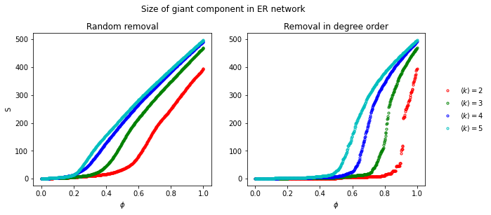

```python
# The code can take a long time

N = 500
trials = 10
ks = np.arange(2,6,1)
phi = np.linspace(0,1,N)

S_rand = np.zeros((len(ks),N))
for y,k in enumerate(ks):
    S_trial = np.zeros((trials,N))
    for t in range(trials):
        S_trial[t] = S_phi(phi,er(N, k/(N-1), 5056+t*y),'rand')
    S_rand[y] = np.mean(S_trial,0)

S_deg = np.zeros((len(ks),N))
for y,k in enumerate(ks):
    S_trial = np.zeros((trials,N))
    for t in range(trials):
        S_trial[t] = S_r(er(N, k/(N-1), 5056+t*y),'deg')[1:]
    S_deg[y] = np.mean(S_trial,0)

fig, ax = plt.subplots(1, 2, figsize=(10,4))
fig.suptitle('Size of giant component in ER network', y=1.02)

for y, (k,c) in enumerate(zip(ks,['r', 'g', 'b', 'c'])):
    ax[0].plot(phi,S_rand[y], 'o'+c, mfc='none', ms=3, label=r'$\langle k\rangle =${}'.format(k))
    ax[1].plot(phi,S_deg[y], 'o'+c, mfc='none', ms=3, label=r'$\langle k\rangle =${}'.format(k))

ax[0].set_title("Random removal")
ax[1].set_title("Removal in degree order")
ax[0].set_ylabel('S')
for a in ax:
    a.set_xlabel(r"$\phi$")
plt.legend(loc='center left', bbox_to_anchor=(1.05,.5), frameon=False)
plt.show()
```

### 1.3.2. Barabási-Albert model

Theoretically, a network obeying power law with exponent $2<\alpha<3$ has a diverging second moment $\langle k^2 \rangle $, so we expect $\phi_c = 0$ in uniform removal. For a real network with finite number of nodes, the second moment is finite but very large, so we expect a very small $\phi_c$. Therefore a scale free network is highly robust and a giant component is present at almost any time.

However, the removal according to degree order will lead to devastating effect. As we can see below, that we only need to remove a relatively small fraction of nodes to destroy the network.

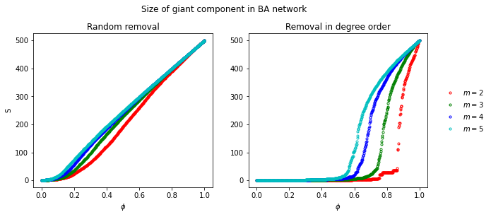

```python
# The code can take a long time

N = 500
trials = 10
ms = np.arange(2,6,1)
phi = np.linspace(0,1,N)

S_rand = np.zeros((len(ms),N))
for y,m in enumerate(ms):
    S_trial = np.zeros((trials,N))
    for t in range(trials):
        S_trial[t] = S_phi(phi,ba(N,m, 5056+t*y),'rand')
    S_rand[y] = np.mean(S_trial,0)

S_deg = np.zeros((len(ms),N))
for y,m in enumerate(ms):
    S_trial = np.zeros((trials,N))
    for t in range(trials):
        S_trial[t] = S_r(ba(N,m, 5056+t*y),'deg')[1:]
    S_deg[y] = np.mean(S_trial,0)

fig, ax = plt.subplots(1, 2, figsize=(10,4))
fig.suptitle('Size of giant component in BA network', y=1.02)

for y, (k,c) in enumerate(zip(ks,['r', 'g', 'b', 'c'])):
    ax[0].plot(phi,S_rand[y], 'o'+c, mfc='none', ms=3, label=r'$m =${}'.format(k))
    ax[1].plot(phi,S_deg[y], 'o'+c, mfc='none', ms=3, label=r'$m =${}'.format(k))

ax[0].set_title("Random removal")
ax[1].set_title("Removal in degree order")
ax[0].set_ylabel('S')
for a in ax:
    a.set_xlabel(r"$\phi$")
plt.legend(loc='center left', bbox_to_anchor=(1.05,.5), frameon=False)
plt.show()
```

# 2. Network synchronization

In the theory of synchronization, we model the system as a collection of oscillators who couple with each other through an interaction matrix. In particular, we can describe a linearly coupled N identical oscillators system by a system of non-linear first order ODEs:

\begin{align*} \frac{d\phi_i}{dt} = F(\phi_i) + \sigma\sum_{j=1}^NC_{ij}H(\phi_j) \end{align*}

Here $\phi_i$ describes the motions of the oscillators, e.g. $\phi_i = v_i(t)$ the velocities in a spring-mass system. $F(\phi_i)$ are the driven forces on individual oscillators, $H(\phi_i)$ is a fixed output function, $\sigma$ denotes the interaction strength, and $C_{ij}$ is called the coupling matrix. In this section, we restricted our discussion to systems with coupling between two oscillators depending only the difference between their outputs. This corresponds to the coupling matrix $C_{ij} = L_{ij}$, where $L_{ij}$ is the graph's Laplacian matrix.

\begin{align*} \frac{d\phi_i}{dt} = F(\phi_i) + \sigma\sum_{j\ \in V(i)} [H(\phi_i) - H(\phi_j)] = F(\phi_i) + \sigma\sum_{j=1}^NL_{ij}H(\phi_j) \end{align*}

## 2.1 Perturbation theory

Then decompose $\xi_i$ into the eigenvector basis of $L_{ij}$, $\xi_i = \sum_j a_{j}v_j$, where $\{ \lambda_1,\lambda_2,...\}$ are the corresponding eigenvalues to the eigenvectors of $L_{ij}$ $\{ v_1,v_2,...\}$ such that

\begin{align*} \sum_j L_{ij}v_j = \lambda_i v_i \end{align*}

The decomposition allow us to write an individual set of ODEs to each eigenvectors

\begin{align*} \frac{dv_i}{dt} = \left[\frac{dF(s)}{dt} + \sigma\lambda_i\frac{dH(s)}{dt}\right]v_i = \Lambda_i(t) v_i \end{align*}

In small time scale, we can assume $\Lambda_i(t) = \Lambda_i$ to be a constant. The solution can be easily solved as

\begin{align*} v_i(t) = v_i(0)e^{\Lambda_i t} \end{align*}

It tells that the evolution of the perturbation is governed by the signs of $\Lambda_i$:

- All $\Lambda_i <0$: The perturbation $\xi_i(t)$ is decaying. The synchronized state is stable.
- Any one $\Lambda_i >0$: The perturbation $\xi_i(t)$ will grow exponentially. The synchronized state is unstable.

The master stability function [2] is defined to be \begin{align*} \Lambda(\alpha) = \max_{s}\left[\frac{dF(s)}{dt} + \alpha\frac{dH(s)}{dt}\right] \end{align*}

which defines the range of $\alpha = \sigma\lambda_i \in [\alpha_\text{low}, \alpha_\text{up}]$ can be taken such that $\Lambda(\alpha) < 0$. The max over $s$ is taken over the trajectory $\frac{ds(t)}{dt} = F(s(t))$. Recall the property of the Laplacian matrix - $L_{ij}$ is symmetric with $\sum_j L_{ij} = 0$ ensures that all $\lambda_i > 0$ with at least one equals to 0. Expressing the eigenvalues as $0 = \lambda_1 <\lambda_2 < ... < \lambda_N = \lambda_\text{max}$.

- $\lambda_1 = 0$ implies $\Lambda_1 = \frac{dF(s)}{dt}$. This is only related to the individual motions of the oscillators, telling whether the system is stable or chaotic subjecting to perturbation when no coupling exists.
- A lower bound $\sigma \lambda_2 > \alpha_\text{low}$ is expected since the coupling should be strong enough such that the oscillators can synchronize.
- An upper bound $\sigma \lambda_\text{max}<\alpha_\text{up}$ exists since divergence can arise if the coupling is too strong.

Such bounds for $\alpha$ are found to typically exist in large class of functions $F$ and $H$ [3]. The two bounds together form an indicator

\begin{align*} \begin{pmatrix} \text{ Parameters from }\\ \text{ network topology } \end{pmatrix} \sim \frac{\lambda_\text{max}}{\lambda_2} < \frac{\alpha_\text{up}}{\alpha_\text{low}} \sim \begin{pmatrix} \text{ Parameters from }\\ \text{ nature of oscillators } \end{pmatrix}\,, \end{align*}

which tells that a network with smaller eigenratio $\frac{\lambda_\text{max}}{\lambda_2}$ favours synchronization.

```python
def lambda_ratio(g):
    eigenvalues = nx.laplacian_spectrum(g)
    return max(eigenvalues)/min(eigenvalues[eigenvalues>1e-6])
```

### 2.1.1. ER network

Proven by [4], ER with average degree $\langle k\rangle = Np$ has the eigenratio

\begin{align*} \frac{\lambda_\text{max}}{\lambda_2} \approx \frac{Np+\sqrt{2p(1-p)N\ln N}}{Np-\sqrt{2p(1-p)N\ln N}} \end{align*}

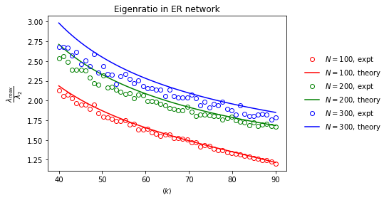

```python
Ns = [100,200,300]
ks = np.linspace(40,90)
trials = 10

plt.figure(figsize=(6,4))
eigenratio = np.zeros((trials,len(ks)), float)
for N,c in zip(Ns, ['r','g','b']):
    for i,k in enumerate(ks):
        for t in range(trials):
            eigenratio[t,i] = lambda_ratio(er(N,k/(N-1),5056+t*N))
    p = ks/(N-1)
    plt.plot(ks, np.mean(eigenratio,0), 'o'+c, mfc='none', label='$N={}$, expt'.format(N))
    plt.plot(ks,(ks+np.sqrt(2*p*(1-p)*N*np.log(N)))/(ks-np.sqrt(2*p*(1-p)*N*np.log(N))), '-'+c, label='$N={}$, theory'.format(N))

plt.title('Eigenratio in ER network')
plt.xlabel(r'$\langle k\rangle$')
plt.ylabel(r'$\dfrac{\lambda_{max}}{\lambda_2}$')
plt.legend(loc='center left', bbox_to_anchor=(1.05,.5), frameon=False)
plt.show()
```

### 2.1.2. Small World Network

A ring world which every nodes are connected to its closest $2K$ neighbour gives an eigenratio of

\begin{align*} \frac{\lambda_\text{max}}{\lambda_2} \approx \frac{N^2}{K(K+1)}\,. \end{align*}

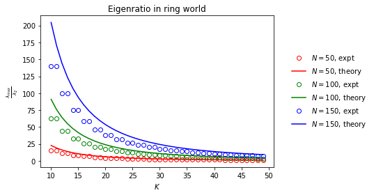

```python
ws = nx.watts_strogatz_graph

Ns = [50,100,150]
K = np.arange(10,50,1)
trials = 10

plt.figure(figsize=(6,4))
eigenratio = np.zeros((trials,len(K)), float)
for N,c in zip(Ns, ['r','g','b']):
    for i,k in enumerate(K):
        for t in range(trials):
            eigenratio[t,i] = lambda_ratio(ws(N,k,0,5056+t*N))
    plt.plot(K, np.mean(eigenratio,0), 'o'+c, mfc='none', label='$N={}$, expt'.format(N))
    plt.plot(K,N**2/K/(K+1), '-'+c, label='$N={}$, theory'.format(N))

plt.title('Eigenratio in ring world')
plt.xlabel(r'$K$')
plt.ylabel(r'$\frac{\lambda_{max}}{\lambda_2}$')
plt.legend(loc='center left', bbox_to_anchor=(1.05,.5), frameon=False)
plt.show()
```

### 2.1.3. Scale free network

By the mean-field result [5], the eigenratio is approximately

\begin{align*} \frac{\lambda_\text{max}}{\lambda_2} \approx \frac{k_\text{max}}{k_\text{min}} \end{align*}

where $k_\text{max}$ and $k_\text{min}$ ar the maximum and minimum degree in the network respectively.

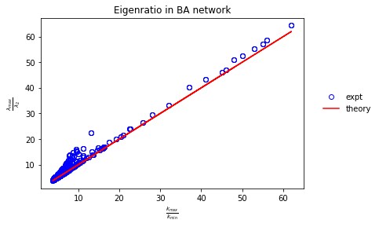

```python
Ns = [50, 100, 150]
ms = np.arange(5,50,1)
trials = 10

eigenratio = np.zeros((trials, len(ms), len(Ns)), float)
deg_ratio = np.zeros((trials, len(ms), len(Ns)), float)

for N in Ns:
    for i,m in enumerate(ms):
        for t in range(trials):
            g = ba(N,m,5056*t+t*N)
            deg_seq = [d for n, d in g.degree()]
            deg_ratio[t,i] = max(deg_seq)/min(deg_seq)
            eigenratio[t,i] = lambda_ratio(g)

plt.figure(figsize=(6,4))
plt.plot(deg_ratio.flatten(), eigenratio.flatten(), 'bo', mfc='none', label='expt')
plt.plot(deg_ratio.flatten(), deg_ratio.flatten(), 'r-', label='theory')

plt.title('Eigenratio in BA network')
plt.xlabel(r'$\frac{k_{max}}{k_{min}}$')
plt.ylabel(r'$\frac{\lambda_{max}}{\lambda_2}$')
plt.legend(loc='center left', bbox_to_anchor=(1.05,.5), frameon=False)
plt.show()
```

## 2.2 Kuramoto model

The Kuramoto model [6] describes a set of oscillators under the coupling in the form:

\begin{align*} \frac{d\phi_i}{dt} = \omega_i + K\sum_{j=1}^N A_{ij}\sin (\phi_i - \phi_j) \end{align*}

where $\phi_i$ and $\omega_i$ are the angular phase and natural frequency of the oscillators respectively. The level of synchronization is quantified by the complex-valued order parameter

\begin{align*} re^{i\psi} = \frac{1}{N}\sum_{j=1}^N e^{i\phi_j} \end{align*}

The quantity on the LHS gives the position of the center of mass if one visualize the phase of each oscillators as moving around the circle of unit radius. $\psi$ gives the average phase of the oscillators, while $r$ is a scalar between 0 and 1, such that $r\approx 1$ corresponds to that the oscillators have almost identical phases.

```python
def kuramoto(t, phi, A, K, w):
    return w + K*np.sum(A*np.sin(np.subtract.outer(phi, phi)),axis=0)

def r(phi):
    return np.abs(np.mean(np.exp(1j*phi),axis=0))

def psi(phi):
    return np.angle(np.mean(np.exp(1j*phi),axis=0))
```

The system can be solved by implementing an ODE solver in python, e.g. `scipy.integrate.solve_ivp()`. Here I visualize the evolution of the phases of the oscillators with a polar plot, with radial axis representing time.

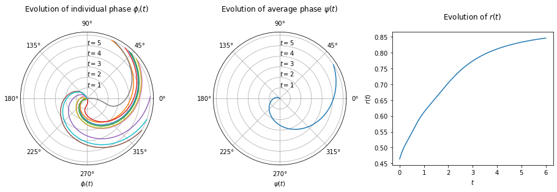

```python
np.random.seed(5056**2)
N = 10
g = er(N, 2/(N-1), 5056*5056) # use ER network as demo.
A = nx.to_numpy_array(g).astype(int)
w = np.random.rand(N) # random natural frequencies
K = 1

phi = np.random.rand(N)*2*np.pi # random initial phase
t_span = [0,6]
sol = solve_ivp(kuramoto, t_span, phi, max_step=1e-2, args=(A,K,w))

plt.figure(figsize=(16,4))
ax1 = plt.subplot(131, projection='polar')
for i in range(N):
    ax1.plot(sol.y[i], sol.t)
ax1.title.set_text('Evolution of individual phase $\phi_i(t)$ \n')
ax1.set_xlabel(r'$\phi_i(t)$')
ax1.set_rlabel_position(90)
ax1.set_yticklabels(['$t = {}$'.format(i+1) for i in range(5)])

ax2 = plt.subplot(132, projection='polar')
ax2.plot(psi(sol.y), sol.t)
ax2.title.set_text('Evolution of average phase $\psi(t)$ \n')
ax2.set_xlabel('$\psi(t)$')
ax2.set_rlabel_position(90)
ax2.set_yticklabels(['$t = {}$'.format(i+1) for i in range(5)])

ax3 = plt.subplot(133)
ax3.plot(sol.t, r(sol.y))
ax3.title.set_text('Evolution of $r(t)$ \n')
ax3.set_xlabel('$t$')
ax3.set_ylabel('$r(t)$')
```

### 2.2.1. Mean field Kuramoto model

A common studied version of Kuramoto model considers $N$ identical oscillators in a fully connected network (i.e. $A_{ij} = 1$ for all $i\neq j$) with same coupling strength $K$ [7]. Multiply the order parameter by $e^{-i\phi_i}$ and take the imaginary part

\begin{align*} \text{Im} \big[re^{i(\psi-\phi_i)}\big] &= \frac{1}{N}\sum_{j=1}^N \text{Im}\big[e^{i(\phi_j-\phi_i)}\big] \\ r\sin (\psi-\phi_i) &= \frac{1}{N}\sum_{j=1}^N \sin (\phi_j-\phi_i) \end{align*}

Substitute into the systems of ODEs of Kuramoto model, we arrive at an expresssion about the evolution of the phases $\phi_i$ of each oscillators coupling to with the mean phase $\psi$ with coupling strength being $r$.

\begin{align*} \frac{d\phi_i}{dt} = \omega_i + KN r\sin (\phi_i-\psi) \end{align*}

\begin{align*} r = \begin{cases} 0 & K^0 < K_c \\ (K^0 - K_c)^\frac{1}{2} & K^0\geq K_c \end{cases} \end{align*}

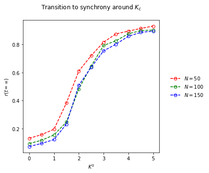

```python
# This code can take a long time
np.random.seed(5056)
N = [50, 100, 150]
K0 = np.linspace(0,5,num=11)
trial = 10
t_span = [0,10]

r_list = np.zeros((len(K0),len(N)))
for j,n in enumerate(N):
    for i,k in enumerate(K0):
        for t in range(trial):
            w = np.random.normal(0,1,n)
            phi = np.random.rand(n)*2*np.pi
            sol = solve_ivp(kuramoto, t_span, phi, max_step=1e-1, args=(1, k/n, w))
            r_list[i,j] += r(sol.y[:,-100:]).mean()

plt.figure(figsize=(5,5))
for j, (n,c) in enumerate(zip(N, ['r','g','b'])):
    plt.plot(K0, r_list[:,j]/trial, 'o--'+c, mfc='none', label=r'$N=${}'.format(n))
plt.xlabel('$K^0$')
plt.ylabel('$r(t=\infty)$')
plt.title('Transition to synchrony around $K_c$\n')
plt.legend(loc='center left', bbox_to_anchor=(1.05,.5), frameon=False)
plt.show()
```

# References

1. Newman, M. E. J.: Networks: An Introduction. Oxford University Press, Oxford (2010).
2. Heagy, J. F., Pecora, L. M. and Carroll, T. L.: Short wavelength bifurcations and size instabilities in coupled oscillator systems, Phys. Rev. Lett. 74, 4185–4188, (1995).
3. Barahona, M. and Pecora, L. M.: Synchronization in small-world systems, Phys. Rev. Lett. 89, 054101, (2002).
4. Mohar, B.: Some applications of Laplace eigenvalues of graphs. In G. Hahn and G. Sabidussi, eds., Graph Symmetry: Algebraic Methods and Applications, Vol. 497 of NATO ASI Series C, Kluwer, pp. 227–275, (1997).
5. Motter, A. E., Zhou, C. and Kurths, J.: Network synchronization, diffusion, and the paradox of heterogeneity, Phys. Rev. E 71, 016116, (2005)
6. Kuramoto, Y.: Chemical Oscillations, Waves, and Turbulence, Springer, (1984).
7. Strogatz, S. H.: From Kuramoto to Crawford: exploring the onset of synchronization in populations of coupled oscillators, Physica D 143, 1–20, (2000).